# Beyond the Bookshelf: Family Influences on Early Language Production

## 7.2 Stress Levels

The Wilcoxon signed-rank test showed a statistically significant difference between morning and evening stress levels (V = 201, p = .00028). This suggests that, on average, participants experience different stress levels in the morning compared to the evening.

Morning vs Evening Stress (Within Groups)

| Group | Statistic | p-value |
| --- | --- | --- |
| With Sibling(s) | 112.5 | 0.0014 |
| No Sibling | 14.0 | 0.0933 |

A paired Wilcoxon signed-rank test was used to compare morning and evening stress levels within households, separated by sibling presence.

In contrast, for parents in single-child households, there was no significant difference between morning and evening stress (W = 14.0, p = 0.0933).

Linear Model: Child Score Predicted by Morning and Evening Stress with Sibling Status

Term

Estimate (β)

Std. Error

t value

p-value

Intercept

38.247

3.548

10.781

0.000

***

Morning Stress

-1.154

0.945

-1.222

0.227

Sibling Present (Yes)

-13.821

4.310

-3.207

0.002

Evening Stress

-2.789

1.178

-2.367

0.022

Interaction (Morning × Sibling)

1.267

1.090

1.162

0.250

Interaction (Evening × Sibling)

2.757

1.292

2.134

0.037

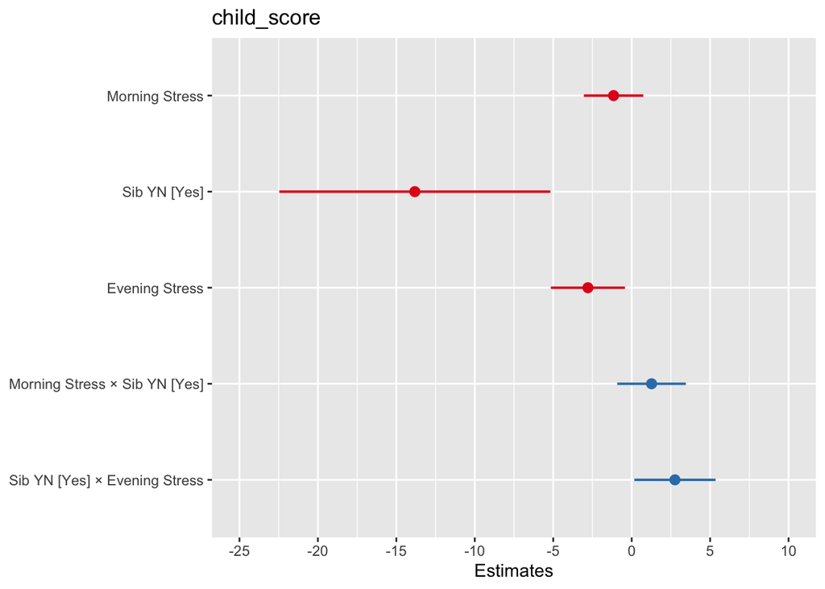

```r
plot_model(sib_stress_lm_model)
```

We examined how morning and evening parental stress and sibling presence influence children’s language and behavioral outcomes, as measured by child score.

Sibling presence was a significant negative predictor (β = -13.82, p = .002), indicating that children with siblings tended to have lower scores than only children.

Evening stress was also negatively associated with child scores (β = -2.79, p = .022), suggesting that higher evening stress levels correspond to lower scores.

The interaction between evening stress and sibling presence was significant (β = 2.76, p = .037), indicating that the negative impact of evening stress on language outcomes is less pronounced when siblings are present. In other words, siblings may buffer the effect of evening stress.

Morning stress alone and its interaction with sibling presence were not statistically significant, suggesting that morning stress does not independently or interactively predict language outcomes in this model.

ANOVA Results: Predicting Language Outcomes from Stress and Sibling Status

| Outcome | Predictor | F value | p-value |
| --- | --- | --- | --- |
| Total Produced | Sib_YN | 0.826 | 0.374 |
| Total Produced | Evening_Stress | 0.304 | 0.587 |
| Total Produced | Morning_Stress | 0.018 | 0.896 |
| Words Produced | Evening_Stress | 7.576 | 0.010 |
| Words Produced | Sib_YN | 2.629 | 0.116 |
| Words Produced | Morning_Stress | 1.043 | 0.316 |
| Words Understood | Evening_Stress | 7.576 | 0.010 |
| Words Understood | Sib_YN | 2.629 | 0.116 |
| Words Understood | Morning_Stress | 1.043 | 0.316 |

We conducted ANOVAs to assess whether Morning Stress, Evening Stress, and Sibling Presence predicted three language outcomes: Words Understood, Words Produced, and Total Words Produced.

Evening Stress emerged as a significant predictor for both Words Understood and Words Produced (F = 7.576, p = .010 for both). This suggests that higher evening stress levels may be associated with lower child language production and comprehension.

However, neither Morning Stress nor Sibling Presence significantly predicted any of the three outcomes (p > .10 in all cases). Similarly, no significant effects were observed for Total Words Produced, indicating that this broader measure of language output may be less sensitive to the household or emotional context.

These findings highlight Evening Stress as a potentially important factor in shaping early language development, particularly in terms of both understanding and producing words.

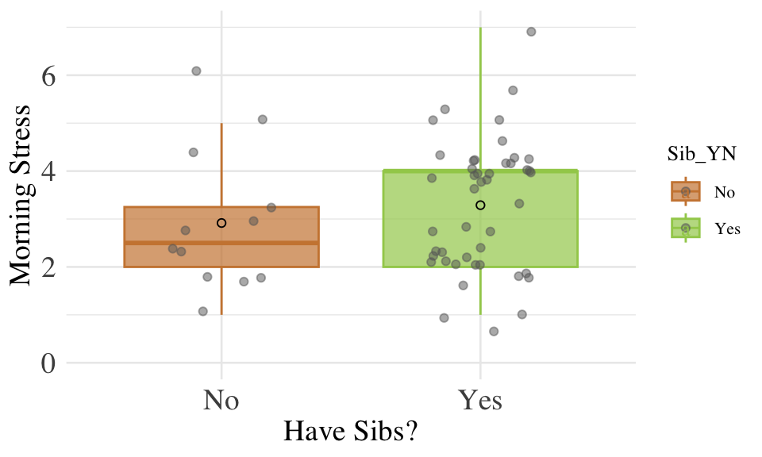

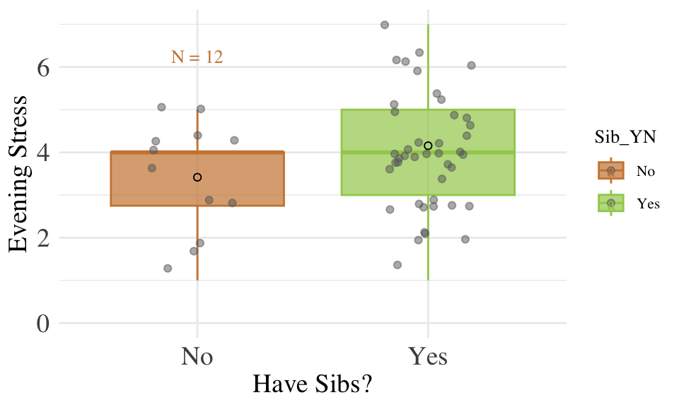

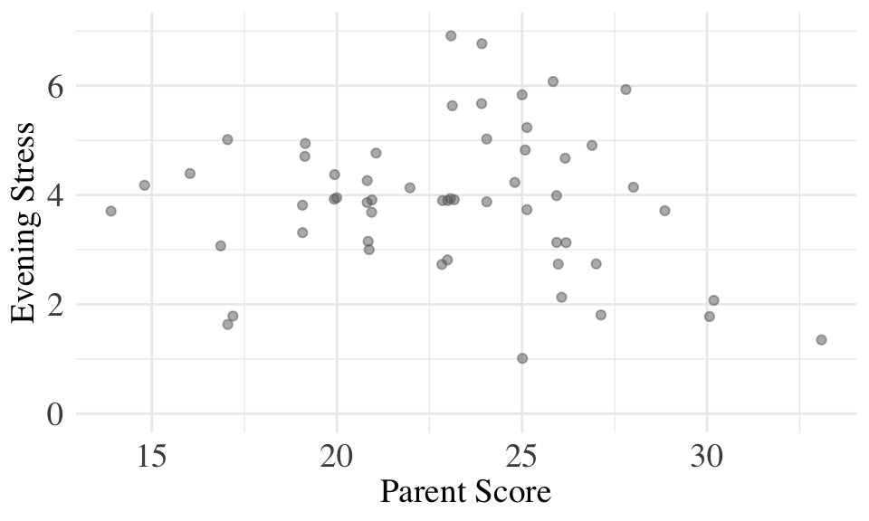

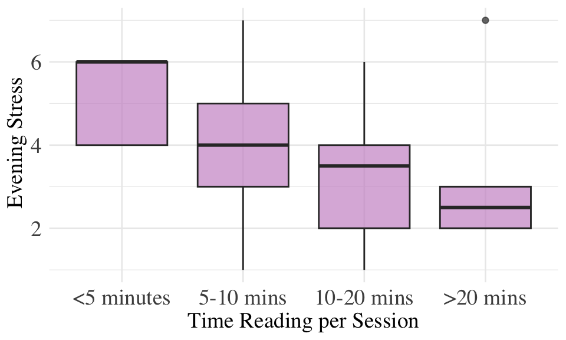